# Getting Started with Text Analysis in R

Christina Maimone

6/14/2021

This tutorial assumes familiarity with dplyr and ggplot2.

To really learn how to work with text:

**Tidytext**: what we’re using here

- https://www.tidytextmining.com/
- https://www.tidytextmining.com/

**Quanteda**: another useful package that has a slightly different workflow

- https://quanteda.io/

A good place to start with Python:

- TextBlob: https://textblob.readthedocs.org/
- TF-IDF in Python: https://programminghistorian.org/en/lessons/analyzing-documents-with-tfidf

# Setup

```r
library(tidyverse)
library(tidytext)
library(knitr)
library(kableExtra)
library(quanteda)
# if you need to install packages, do the following:
# install.packages(c("tidyverse", "tidytext", "knitr", "kableExtra", "quanteda"))
```

We’re going to work with a collection of press releases from members of the US Senate from 2020-03-10 to 2020-06-30 – the first ~3.5 months of coronovirus in the US. The press releases were collected via the [ProPublica API](https://projects.propublica.org/api-docs/congress-api/statements/#statements) for Congressional Statements. The text was extracted from the collected web pages mostly with the Python [newspaper](https://newspaper.readthedocs.io/en/latest/) library.

```r
pr <- read_csv("pr.csv")   # if the file is local
# read file from online, if you don't have the file locally
# pr <- read_csv("https://raw.githubusercontent.com/nuitrcs/r-quick-text/main/pr.csv")

pr
```

```
## # A tibble: 9,847 x 8
##    person_id name    state party male  date       title           text
##    <chr>     <chr>   <chr> <chr> <lgl> <date>     <chr>           <chr>
##  1 E000285   Michae… WY    R     TRUE  2020-06-01 Enzi applauds … "U.S. Senator…
##  2 E000295   Joni E… IA    R     FALSE 2020-06-01 Ernst Resumes … "WASHINGTON—U…
##  3 M001183   Joe Ma… WV    D     TRUE  2020-06-02 Manchin Votes … "Manchin Vote…
##  4 V000128   Chris … MD    D     TRUE  2020-06-02 Van Hollen, He… "Van Hollen, …
##  5 M000934   Jerry … KS    R     TRUE  2020-06-02 Sen. Moran Ann… "WASHINGTON –…
##  6 H001046   Martin… NM    D     TRUE  2020-06-02 Heinrich, Tonk… "Heinrich, To…
##  7 H001046   Martin… NM    D     TRUE  2020-06-02 Heinrich, Nati… "Heinrich, Na…
##  8 H001046   Martin… NM    D     TRUE  2020-06-02 N.M. Delegatio… "N.M. Delegat…
##  9 M000639   Robert… NJ    D     TRUE  2020-06-02 Menendez on Ov… "Senator Bob …
## 10 W000802   Sheldo… RI    D     TRUE  2020-06-02 Sen. Whitehous… "June 2, 2020…
## # … with 9,837 more rows
```

## Dataset Basics

What’s in the dataset?

Number of Senators

```r
# pr is the name of the data frame
# n_distinct counts the number of different values
# person_id is the column we're summarizing -- what we're counting unique values of
summarize(pr, n_distinct(person_id))
```

```
## # A tibble: 1 x 1
##   `n_distinct(person_id)`
##                     <int>
## 1                      97
```

Almost all of them – missing a few

Number of press releases

```r
nrow(pr)  # number of rows (each row is a press release)
```

```
## [1] 9847
```

Press releases per Senator – distribution

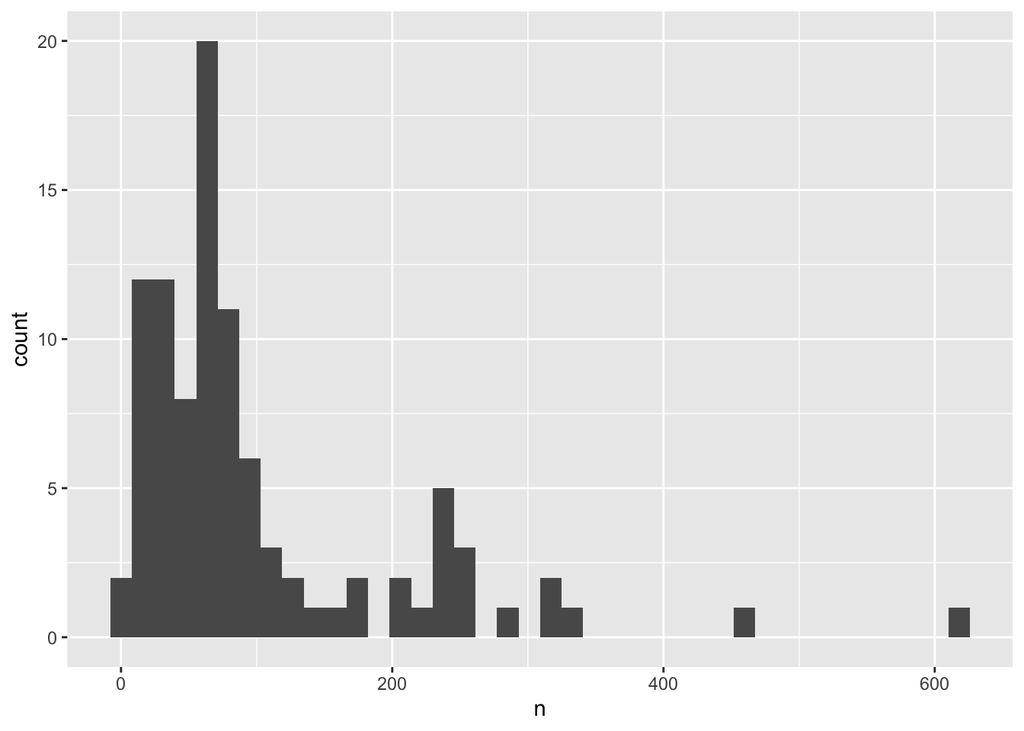

```r
count(pr, person_id) %>%   # frequency table for person_id -- number of times each ID appears
  ggplot(aes(x=n)) +   # set up the plot -- we're going to plot the n count variable created by count()
  geom_histogram(bins=40)  # making a histogram with 40 bins
```

A few very vocal folks:

```r
count(pr,                   # data frame we're working with
      name, party, state,   # variables to group by -- we're using multiple to keep them in the output
      sort=TRUE)            # sort the results with the most frequent values first
```

```
## # A tibble: 97 x 4
##    name                party state     n
##    <chr>               <chr> <chr> <int>
##  1 Joni Ernst          R     IA      622
##  2 Robert Menendez     D     NJ      460
##  3 Rob Portman         R     OH      329
##  4 Dianne Feinstein    D     CA      317
##  5 Charles E. Grassley R     IA      313
##  6 Sherrod Brown       D     OH      279
##  7 Marco Rubio         R     FL      259
##  8 Elizabeth Warren    D     MA      253
##  9 Susan Collins       R     ME      253
## 10 Jon Tester          D     MT      237
## # … with 87 more rows
```

PRs by date:

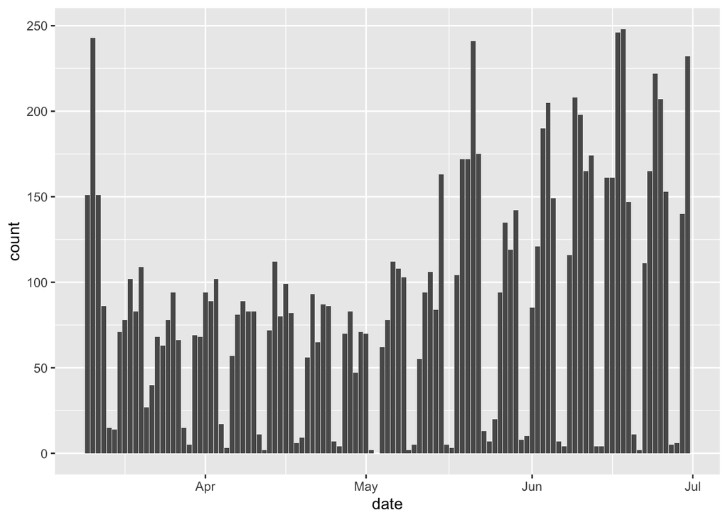

```r
ggplot(pr, aes(x=date)) +   # plot the date variable on the x-axis
  geom_bar()                # make a bar plot (count # of times each date appears and plot that)
```

You can see a weekly cycle to it.

Look at the text of a few press releases:

```r
# cat so that line breaks are printed
cat(pr$text[1:4],   # first 4 in the data set
    sep="\n\n*******\n\n")  # put this between press releases so that we know when one stops
```

```
## U.S. Senator Mike Enzi, R-Wyo., issued the following statement after the Environmental Protection Agency (EPA) finalized a new rule concerning Section 401 of the Clean Water Act. The EPA’s announcement would set a one-year deadline for states and tribes to certify or reject proposed projects like…
##
## *******
##
## WASHINGTON—U.S. Senator Joni Ernst (R-IA) resumed her 99 County Tour for 2020 last week, hearing directly from Iowans as the state works to safely reopen. Following public health guidelines, Ernst visited with biofuel producers, local employers, and received an update on flood recovery efforts fr…
##
## “Every year, my 99 County Tour gives me the opportunity to hear from Iowans directly, and that’s all the more important during this difficult time. As we take steps to safely reopen our state and get Iowans back to work, it’s crucial that we continue to communicate and work together—at the federa…
##
## Last week, Senator Ernst visited Green Plains’ facility in Fremont County to discuss her efforts to support the state’s hardworking producers. Ernst also visited with major employers in Union and Appanoose Counties, learned more about a public-private partnership to increase connectivity in Decat…
##
## Since the outbreak of this pandemic, Senator Ernst has continued to connect with Iowans from every corner and county of the state. To date during COVID-19, Ernst has held eleven telephone town halls to help folks get access to the relief available to them, including Iowa’s seniors and agriculture…
##
## Senator Ernst has also held question and answer sessions with business owners and employees from across Iowa’s economy, including health care workers, farmers, small business owners, franchise owners, bankers, pork producers, cattlemen, public housing officials, restaurant owners, hotel and lodgi…
##
## ###
##
## *******
##
## Manchin Votes Against Special Inspector General For Pandemic Recovery Nominee
##
## Washington, DC – Today U.S. Senator Joe Manchin (D-WV) released the following statement on his opposition to the nomination of Brian Miller to be the Special Inspector General for Pandemic Recovery.
##
## “The COVID-19 pandemic has affected every American and West Virginian and has changed the way we go about our daily lives. This terrible virus has killed more than 100,000 Americans and 78 West Virginians in the past few months. The Special Inspector General for Pandemic Recovery is tasked with e…
##
## *******
##
## Van Hollen, Heinrich, Tonko Call for Inclusion of Clean Energy Workforce Support in COVID-19 Economic Recovery Packages
##
## The lawmakers’ letter comes as nearly 600,000 clean energy workers have experienced job loss as a result of the COVID-19 pandemic
##
## U.S. Senators Chris Van Hollen (D-Md.) and Martin Heinrich (D-N.M.) and U.S. Representative Paul Tonko (D-N.Y.) are urging congressional leaders to prioritize a clean energy recovery plan in upcoming economic relief and recovery packages to deal with the impacts of the novel coronavirus (COVID-19…
##
## The lawmakers’ call for urgency comes as nearly 600,000 clean energy workers have experienced unemployment as a result of the COVID-19 pandemic. Closures due to COVID-19 have led to clean energy sector manufacturing reductions, supply chain issues, decreased installation of renewable energy, and …
##
## “As Congress works to help the American economy recover, we must ensure robust investments are made to spur growth in renewable energy, energy storage, energy efficiency, clean vehicles, clean and efficient infrastructure, clean fuels, and workforce development,” the lawmakers wrote. “These inves…
##
## In an effort to spur production and save money for consumers, the bicameral group of members is also calling for an extension of and increased flexibility for clean energy tax incentives.
##
## The lawmakers continued, “The myriad devastating effects of the COVID-19 pandemic are staggering, and further compounded by a potentially prolonged economic downturn. In the midst of urgent action to staunch these losses and rebuild, it can be difficult to also focus on our country’s long-term ne…
##
```

[output cut: 10 more lines]

```
## Nationally, approximately 594,300 clean energy workers have lost their jobs during the pandemic, while many others have been temporarily furloughed or underemployed. This total represents an approximately 17.4% decrease in clean energy employment. To put this in perspective, in April, the nationa…
##
## Closures due to COVID-19 have also led to manufacturing reductions, supply chain issues, and decreased installation of renewable energy. For example, the Solar Energy Industries Association expects only 3GW of solar capacity will be installed in Q2 2020, a 37% decrease from pre-COVID-19 projectio…
##
## As Congress works to help the American economy recover, we must ensure robust investments are made to spur growth in renewable energy, energy storage, energy efficiency, clean vehicles, clean and efficient infrastructure, clean fuels, and workforce development. These investments should both spur …
##
## In addition, a number of the existing clean energy tax incentives for individuals and businesses are phasing down or expiring. Extending and providing additional flexibility for these credits, which spur production and save money for consumers, is another important facet of a quick recovery.
##
## As we work to rebuild the clean energy workforce and sector, we must ensure we are creating high quality jobs that uphold fair labor standards and collective bargaining agreements. Federal investments must include provisions to work with organized labor.
##
## The myriad devastating effects of the COVID-19 pandemic are staggering, and further compounded by a potentially prolonged economic downturn. In the midst of urgent action to staunch these losses and rebuild, it can be difficult to also focus on our country’s long-term needs. However, the impendin…
##
## Thank you for your consideration of this important matter.
##
## Sincerely,
```

# Exploring the Dataset

We’ll start exploring the text by looking at common words.

## Search for specific words/phrases

How many press releases have “covid” in them?

```r
# one line
count(pr, str_detect(text, fixed("covid", ignore_case=TRUE)))
```

```
## # A tibble: 2 x 2
##   `str_detect(text, fixed("covid", ignore_case = TRUE))`     n
##   <lgl>                                                  <int>
## 1 FALSE                                                   4550
## 2 TRUE                                                    5297
```

```r
# pr is the data frame name
# str_detect is the function to use to see if one string is in another
# text is the name of the column
# we use fixed() because we're searching for a fixed string (not regex pattern)
# "covid" is the search term
# ignore_case=TRUE makes the search case insensitive
```

### EXERCISE

*Make sure you’re run the setup code chunks above to load the libraries and the data.*

For comparison, how many press releases mention “state” (such as “in our great state, …”)?

Try a few other search terms too.

## Common Words

Now, we don’t want to have to guess all of the words that appear – how can we get a list of the most common words?

First, we need to transform our dataset to have words. Instead of making a document-term matrix at this point, we’ll make a data frame with one word per row. We’ll keep all of the extra metadata in our data frame since the file we’re working with isn’t huge. For large files, you wouldn’t want to keep all of the metadata because it gets copied many times and will make the resulting object too big.

We will also add an identifier for each row, so we know which press release each word came from if we want to use that.

```r
words <- pr %>%
  mutate(pr_id = 1:nrow(pr)) %>%  # add an identifier for each press release
  unnest_tokens("word", text)
```

```r
head(words)
```

```
## # A tibble: 6 x 9
##   person_id name      state party male  date       title             pr_id word
##   <chr>     <chr>     <chr> <chr> <lgl> <date>     <chr>             <int> <chr>
## 1 E000285   Michael … WY    R     TRUE  2020-06-01 Enzi applauds Cl…     1 u.s
## 2 E000285   Michael … WY    R     TRUE  2020-06-01 Enzi applauds Cl…     1 sena…
## 3 E000285   Michael … WY    R     TRUE  2020-06-01 Enzi applauds Cl…     1 mike
## 4 E000285   Michael … WY    R     TRUE  2020-06-01 Enzi applauds Cl…     1 enzi
## 5 E000285   Michael … WY    R     TRUE  2020-06-01 Enzi applauds Cl…     1 r
## 6 E000285   Michael … WY    R     TRUE  2020-06-01 Enzi applauds Cl…     1 wyo
```

Now that we have a dataset with words, we can just count them:

```r
# words is the data frame
# word is the column name
# sot the output to see most common
count(words, word, sort=TRUE)
```

```
## # A tibble: 48,566 x 2
##    word       n
##    <chr>  <int>
##  1 the   312881
##  2 to    229703
##  3 and   206191
##  4 of    149136
##  5 in     95456
##  6 for    78531
##  7 a      76583
##  8 that   64173
##  9 on     44112
## 10 this   43448
## # … with 48,556 more rows
```

This is not a surprising list. These are the most common words in almost any English text.

There are two ways we could look for more interesting words.

1. If we do really just want the most common words, we could eliminate “stop words” using a list – this is just a list of very common words. There is no one canonical list of stop words – the contents and length vary, and you could make one yourself customized to your use case.
2. We can use TF-IDF scores (term-frequency inverse document frequency), which is a way of normalizing the frequency of words in a document or group of documents compared to the frequency across the entire set of documents – so find words that are more common in a document or set of documents than they are in the full set of documents.

### Remove Stop Words

The tidytext package has a built-in data frame of stopwords: `stop_words`. We can combine this with our words data frame to remove these words

```r
words %>%
  anti_join(stop_words, by="word") %>%  # remove from words those that have a match in stop_words
  count(word, sort=TRUE)
```

```
## # A tibble: 47,875 x 2
##    word            n
##    <chr>       <int>
##  1 health      25401
##  2 19          23272
##  3 covid       23157
##  4 senator     19451
##  5 act         18672
##  6 u.s         18488
##  7 federal     15337
##  8 pandemic    14984
##  9 coronavirus 14019
## 10 senate      13166
## # … with 47,865 more rows
```

These are reasonable. We could do these for different groups.

We can compute the list just for a specific group:

```r
# just democrats
words %>%
  filter(party == "D") %>%   # specify one group at a time
  anti_join(stop_words, by="word") %>%
  count(word, sort=TRUE)
```

```
## # A tibble: 34,442 x 2
##    word            n
##    <chr>       <int>
##  1 health      17137
##  2 19          15099
##  3 covid       15089
##  4 senator     10854
##  5 act         10793
##  6 u.s         10360
##  7 federal      9604
##  8 pandemic     9592
##  9 senators     8639
## 10 coronavirus  8428
## # … with 34,432 more rows
```

Or we could make a list for each party, but we’d need to drop the counts to make this manageable to see – we’ll just look at the rank order of words

```r
words %>%
  anti_join(stop_words, by="word") %>%
  group_by(party) %>%   # variable that defines our groups
  count(word, sort=TRUE) %>%
  mutate(rank = row_number()) %>%
  select(party, rank, word) %>%
  pivot_wider(names_from=party, values_from=word)
```

```
## # A tibble: 34,442 x 4
##     rank D           R           ID
##    <int> <chr>       <chr>       <chr>
##  1     1 health      senator     senator
##  2     2 19          19          health
##  3     3 covid       u.s         maine
##  4     4 senator     covid       king
##  5     5 act         health      pandemic
##  6     6 u.s         act         act
##  7     7 federal     senate      coronavirus
##  8     8 pandemic    federal     u.s
##  9     9 senators    coronavirus national
## 10    10 coronavirus pandemic    care
## # … with 34,432 more rows
```

### EXERCISE

*Make sure you have the `words` data frame. If you haven’t been running the code above, make the data frame first:*

```r
# eval=FALSE above just prevents this code from being run when I make an HTML version -
# you can still run the code manually

words <- pr %>%
  mutate(pr_id = 1:nrow(pr)) %>%
  unnest_tokens("word", text)
```

Now, find the most common words, excluding stop words, by gender of the Senator – there is a column called `male` with TRUE and FALSE values in it.

### TF-IDF

The most common words are very similar across groups. So what if we want to know what words that are more “Democratic” or “Republican” – what words differentiate these two groups – are used disproportionately more by one group than the other? Then we can use TF-IDF.

TF-IDF can be computed at the document level (each press release), but we can do it for whole groups by considering all text written by each group to be a single document. We use the grouping variable (here: party) as the document ID.

```r
words %>%
  count(party, word) %>%  # we need to count times each word appears for each group (party)
  bind_tf_idf(word, party, n) %>%   # adds columns for tf, idf, tf-idf
  arrange(desc(tf_idf))  # sort the results to show us most distinctive terms regardless of party
```

```
## # A tibble: 74,944 x 6
##    party word                n       tf   idf   tf_idf
##    <chr> <chr>           <int>    <dbl> <dbl>    <dbl>
##  1 R     iowans           1996 0.000850 1.10  0.000933
##  2 R     iowa’s           1644 0.000700 1.10  0.000769
##  3 ID    chile              25 0.000331 1.10  0.000364
##  4 R     ernst’s           627 0.000267 1.10  0.000293
##  5 R     phase            1257 0.000535 0.405 0.000217
##  6 ID    dcf.vermont.gov    12 0.000159 1.10  0.000175
##  7 ID    mlti               10 0.000133 1.10  0.000146
##  8 ID    unsubscribe         9 0.000119 1.10  0.000131
##  9 R     kentucky          637 0.000271 0.405 0.000110
## 10 D     transit           910 0.000263 0.405 0.000107
## # … with 74,934 more rows
```

Some of these words aren’t used very frequently. So we might want to have a cut-off for how many times a word appears overall.

Let’s filter on word frequency, and convert to rankings like we did above:

```r
words %>%
  count(party, word) %>%
  filter(n >= 100) %>%   # words used at least 100 times overall
  group_by(party) %>%
  bind_tf_idf(word, party, n) %>%
  arrange(desc(tf_idf)) %>%
  mutate(rank = row_number()) %>%  # compute the rank for each term
  select(party, rank, word) %>%    # keep just the party, words, and rank - drop the counts
  pivot_wider(names_from=party, values_from=word)  # make one column of words for each party
```

```
## # A tibble: 3,271 x 4
##     rank ID        R      D
##    <int> <chr>     <chr>  <chr>
##  1     1 vermont   ernst  ensure
##  2     2 sanders   iowa   new
##  3     3 19        iowans markey
##  4     4 2020      small  including
##  5     5 a         relief ma
##  6     6 act       iowa’s relief
##  7     7 all       work   merkley
##  8     8 also      so     emergency
##  9     9 american  but    access
## 10    10 americans here   administration
## # … with 3,261 more rows
```

You can see that some stopwords are still in here - this reflects different language use by the groups (vs. content).

In an analysis, we might want to filter out places and additional words that are specific to this context that we want to ignore.

### EXERCISE

Now, use tf-idf to find top words by the gender of the Senator (variable: `male`)

# Turning Text into Data

Next we turn to a few ways we could turn our text into some type of data frame of numeric values.

## Document-Term Matrix

First, how do we convert our data from the long form `words` data frame above into a document-term matrix with one row per document and one column per term?

There are a few different versions of this – they create objects expected by other text analysis packages `tm` and `quanteda`. We’ll do the version for quanteda here.

However, before we do this, we are going to filter the data to only include terms that show up 10 times. Otherwise, we’ll have a very large DTM that isn’t much use to us. 10 is an arbitrary cut-off - you could use a different value.

This will take approximately 30-40 seconds to run (code not run when file knitted to html).

```r
low_freq <- count(words, word) %>%
  filter(n < 10)

dtm <- words %>%
  anti_join(low_freq, by="word") %>%  # remove words with low overall frequency
  count(pr_id, word) %>%  # we need count of terms per document to start with
  cast_dfm(pr_id,  # column identifying each press release
           word,   # column with the "terms"
           n)      # column with the count -- n is created by count() above
```

```r
dtm
```

Even after filtering out low frequency words, we still have 14k+ different words in our matrix. We could do further filtering – removing numbers, for example. This is stored as a sparse matrix, not a normal data frame, because it’s large and has a lot of 0s in it.

But we can still index it like a data frame. In particular, we could pull specific columns for specific terms:

```r
dtm[,"abused"]
```

```r
colnames(dtm)
```

Instead of filling the DTM with the word counts, you can also do TF-IDF or convert it to binary 0/1 indicators - what you want depends on the context.

You could also process the words further first, for example, by converting all words to their stem (the core part of the word), so that words like dogs and dog are combined together. Whether this helps depends on the specifics of your analysis case.

You could use individual term vectors here in a predictive model – we’re not going to build a model here today. Otherwise, the main reason to convert the data is to pass it to another package that does something you want. But, if you want to use something in quanteda, for example, you may want to put your data in the format it wants from scratch to take advantage of the many cleaning and processing functions included in that package.

## Dictionaries

Let’s build a short, naive dictionary to match against our documents to see how many press releases mention education topics. We’ll put the terms in a data frame, so we can join it with `words`.

```r
education <- data.frame(word = c("education",
                                 "school",
                                 "schools",
                                 "teacher",
                                 "teachers",
                                 "student",
                                 "students"),
                        weight = 1)  # this will just give us something to add up later
```

All of the terms here are lowercase because our `words` data is all lowercase.

We can join this data to `words` and count how many times one of these terms appear in each press release:

```r
words %>%
  left_join(education, by="word") %>%
  group_by(pr_id) %>%   # compute for each press release
  summarize(education = sum(weight, na.rm=TRUE)) %>%  # total number of keywords
  arrange(desc(education))
```

```
## # A tibble: 9,847 x 2
##    pr_id education
##    <int>     <dbl>
##  1   825       126
##  2   840       126
##  3  2118       126
##  4   769       122
##  5   889       121
##  6   773       118
##  7   895       118
##  8   787       116
##  9   853       106
## 10  1521       106
## # … with 9,837 more rows
```

Let’s look at a top document - remember that `pr_id` is the row number in `pr`

```r
cat(pr$text[825])
```

```
## Baldwin, Democrats Push DeVos to Issue Clear Guidance for Schools and Families Following Widespread School Closures
##
## Baldwin, Democrats push for DeVos to address school lunches, online learning, and federal financial aid and student loans
##
## Senators: “We urge the U.S. Department of Education to consider several serious issues related to school closure.”
##
## WASHINGTON, D.C. – U.S. Senator Tammy Baldwin (D-WI), a member of the Senate Committee on Health, Education, Labor and Pensions (HELP), joined 32 of her Democratic colleagues in urging Secretary of Education Betsy DeVos to provide clarity and guidance for school districts and institutions of high…
##
## In a letter to Secretary DeVos led by Senator Patty Murray (D-WA), ranking member of the Senate HELP Committee, the Senators stressed that it is crucial that the Department of Education provide direction as schools prepare to make difficult decisions about closures.
##
## “Increasing numbers of K-12 schools and institutions of higher education are considering school closures in order to mitigate the spread of the virus. We urge the U.S. Department of Education to consider several serious issues related to school closure as it works with school districts, state edu…
##
## As the coronavirus continues to spread throughout the country, many schools have already closed and more are likely to follow suit in the coming weeks. School closures particularly affect students who are food or housing insecure, students who cannot access online learning because they do not hav…
##
## Specifically, the Senators urged the Department of Education to provide guidance on a number of issues including:
##
## How K-12 schools should ensure students can access school lunch programs;
##
## How schools using online learning should meet the needs of students without computers or access to internet and students with disabilities;
##
## How schools should ensure students receive a high-quality education online;
##
## How schools should provide mental health services remotely;
##
## How colleges and universities should help students enrolled in programs of study abroad affected by the spread of the virus;
##
## How colleges and universities should help students avoid using up their federal financial aid if they have to leave school due to the spread of the virus;
##
## How the Department of Education will help federal student loan borrowers if they cannot work due to the spread of the virus;
##
## How the Department of Education will adjust financial aid for families affecting by the spread of the virus (including job losses or closures).
##
## Considering the urgency of the crisis, the Senators asked for a response no later than March 24. In addition to Senators Baldwin and Murray, the letter was signed by Senators Sheldon Whitehouse (D-RI), Jack Reed (D-RI), Cory Booker (D-NJ), Catherine Cortez Masto (D-NV), Chris Van Hollen (D-MD), B…
##
## Senator Baldwin and other Democrats in the Senate have already pushed for answers from the Department of Education on how they will work to protect students, teachers and staff during the coronavirus crisis.
##
## The full text of the letter is below and HERE.
##
## March 10, 2020
##
```

[output cut: 14 more lines]

```
## On February 27, 2020, the Department announced it had launched an internal Coronavirus Task Force led by Mick Zais, Deputy Secretary of Education. On March 4, 2020, the Office for Civil Rights provided guidance about educational institutions’ responsibility to address bullying and harassment of s…
##
## We do not yet know the scale at which K-12 schools and IHEs across the country may need to close in order to help contain the spread of COVID-19, but we urge you to do everything you can to ensure you are continuing to prepare stakeholders for a variety of scenarios. To date, over a dozen countri…
##
## As schools prepare to make these difficult decisions, they are faced with many legal and practical uncertainties and are looking for clear guidance and direction from the Department.
##
## We are especially concerned by the adverse impact of school closures on certain students and families. In K-12 schools, many families rely on the Federal School Lunch Program and may experience food insecurity if they can no longer access meals at school. Few school districts have experience prov…
##
## COVID-19 also could severely impact many students in higher education, as well as federal loan borrowers. Students rely on their colleges for on-campus food and housing services. American students enrolled abroad in foreign colleges face barriers to continuing their education, whether online or a…
##
## We urge you to consider these issues and provide us, and the public, answers to the following questions by no later than March 24, 2020:
##
## What communication has the Department had with the United States Department of Agriculture (USDA) about the school lunch program to ensure students in schools that have closed or will close continue to have access to meals? What communication has the Department had with the United States Departme…
##
## We also look forward to reading your response to the letter sent by Senator Murray and several members of the Health, Education, Labor, and Pensions Committee on March 2, 2020, regarding how the Department is preparing for the potential spread of the outbreak and working with other federal agenci…
```

### EXERCISE

Make a dictionary of coronavirus related terms. Apply it to the press releases.

## Sentiment

Sentiment is a measure of how positive or negative in sentiment (tone) a piece of text is. One simple way to compute this is to use dictionaries of weighted terms. tidytext includes some of these dictionaries that we can use in the `sentiments` data frame (or use the get_sentiments function to retrieve other versions from the textdata package, which you’d need to install).

```r
head(sentiments)
```

```
## # A tibble: 6 x 2
##   word       sentiment
##   <chr>      <chr>
## 1 2-faces    negative
## 2 abnormal   negative
## 3 abolish    negative
## 4 abominable negative
## 5 abominably negative
## 6 abominate  negative
```

```r
words %>%
  left_join(sentiments, by="word") %>%
  group_by(pr_id) %>%
  summarize(positive = sum(sentiment == "positive", na.rm=TRUE),  # count positive words
            negative = sum(sentiment == "negative", na.rm=TRUE),  # count negative words
            overall = positive - negative,  # take the difference between these
            total_words = n(),  # length of the document overall - n() counts number of lines, which = words here
            sentiment_prop = overall/total_words) %>%  # normalize by document length
  arrange(desc(abs(sentiment_prop)))  # look at strongest sentiment in either direction: abs = absolute value
```

```
## # A tibble: 9,847 x 6
##    pr_id positive negative overall total_words sentiment_prop
##    <int>    <int>    <int>   <int>       <int>          <dbl>
##  1  3166        1        0       1           4          0.25
##  2  7787        0        3      -3          12         -0.25
##  3  7499        1        0       1           5          0.2
##  4  7821        2        0       2          11          0.182
##  5   306        0        3      -3          17         -0.176
##  6   483        0        1      -1           6         -0.167
##  7  1032        1        0       1           6          0.167
##  8  2380        0        3      -3          18         -0.167
##  9  8577        1        0       1           6          0.167
## 10  4729        0        2      -2          13         -0.154
## # … with 9,837 more rows
```

```r
cat(pr$text[7787])
```

```
## Video: Cruz on Fox Biz Blasts Big Tech for Arrogance & Brazen Lawlessness
```

An example with more words:

```r
cat(pr$text[7280])
```

```
## WASHINGTON, D.C. – This week, U.S. Senators Thom Tillis (R-NC), Dan Sullivan (R-AK), and Tammy Baldwin (D-WI) introduced a bipartisan resolution designating the month of June as National Post-Traumatic Stress Awareness Month and June 27 as National Post-Traumatic Stress Awareness Day. Representat…
##
## “North Carolina is the proud home of nearly one million veterans, and fully honoring and caring for them requires understanding and addressing the invisible wounds of war, including post-traumatic stress,” said Senator Tillis. “I will continue to work on bipartisan solutions to make sure that our…
##
## Below is the full text of the resolution:
##
## Designating June 2020 as ``National Post-Traumatic Stress Awareness Month'' and June 27, 2020, as ``National Post-Traumatic Stress Awareness Day''.
##
## Whereas the brave men and women of the Armed Forces, who proudly serve the United States—
##
## (1) risk their lives to protect the freedom, health, and welfare of the people of the United States; and
##
## (2) deserve the investment of every possible resource to ensure their lasting physical, mental, and emotional well-being;
##
## Whereas, since the events of September 11, 2001, nearly 2,800,000 members of the Armed Forces have deployed overseas and served in places such as Afghanistan and Iraq;
##
## Whereas the current generation of men and women in the Armed Forces has sustained a high rate of operational deployments, with many members of the Armed Forces serving overseas multiple times, placing those members at high risk of enduring traumatic combat stress;
##
## Whereas, when left untreated, exposure to traumatic combat stress can lead to severe and chronic post-traumatic stress responses, which are commonly referred to as post-traumatic stress disorder (referred to in this preamble as “PTSD”) or post-traumatic stress injury;
##
## Whereas many men and women of the Armed Forces and veterans who served before September 11, 2001, live with mental health needs from post-traumatic stress and remain at risk for responses to that stress;
##
## Whereas many post-traumatic stress responses remain unreported, undiagnosed, and untreated due to a lack of awareness about post-traumatic stress and the persistent stigma associated with mental health conditions;
##
## Whereas post-traumatic stress significantly increases the risk of post-traumatic stress responses, including anxiety, depression, homelessness, substance abuse, and suicide, especially if left untreated;
##
## Whereas the Secretary of Veterans Affairs reports that—
##
## (1) between 11 and 20 percent of veterans who served in Operation Iraqi Freedom or Operation Enduring Freedom have post-traumatic stress in a given year;
##
## (2) approximately 12 percent of veterans who served in the Persian Gulf War have post-traumatic stress in a given year; and
##
## (3) approximately 30 percent of veterans who served in the Vietnam era have had post-traumatic stress in their lifetimes;
##
## Whereas public perceptions of post-traumatic stress as a mental health disorder create unique challenges for veterans seeking employment;
##
## Whereas the Department of Defense, the Department of Veterans Affairs, veterans service organizations, and the private and public medical community have made significant advances in the identification, prevention, diagnosis, and treatment of post-traumatic stress and the symptoms of post-traumati…
##
## Whereas increased understanding of post-traumatic stress can help eliminate stigma attached to the mental health issues of post-traumatic stress;
##
```

[output cut: 38 more lines]

```
## (B) understanding that personal interactions can save lives and advance treatment;
##
## (4) welcomes the efforts of the National Center for Post-Traumatic Stress Disorder of the Department of Veterans Affairs and local Vet Centers (as defined in section 1712A(h) of title 38, United States Code) to provide assistance to veterans who are suffering from the effects of post-traumatic st…
##
## (5) encourages the leadership of the Armed Forces to support appropriate treatment of men and women of the Armed Forces who suffer from post-traumatic stress;
##
## (6) recognizes the impact of post-traumatic stress on the spouses and families of members of the Armed Forces and veterans; and
##
## (7) respectfully requests that the Secretary of the Senate transmit a copy of this resolution to—
##
## (A) the Secretary of Veterans Affairs; and
##
## (B) the Secretary of Defense.
##
## ###
```

This is a good example of a document that seems negative, because it covers a negative topic, but that we wouldn’t necessarily consider negative overall because it’s a bill to help people. These types of discrepancies are common. Remember: many sentiment analyzers were built using data from a different context than what you may be looking at.

We could use variations on these sentiment scores (positive, negative, overall, normalized, etc.) as variables in some other analysis.

People have created slightly more sophisticated versions of sentiment analyzers that take into account things like negation. These methods need the full original text so parts of speech and dependencies can be parsed. But these still use dictionaries of terms as the core of the measure. Try the sentimentr package for other versions of sentiment analysis.

## Really Simple (BAD!) Model

Using the top 200 terms by tf-idf for each party, how well can we predict the party of the Senator who wrote each press release? We’ll exclude independents for this.

**NOTE**: This is bad - we are skipping a lot of steps. This is only indended as a quick example of how you could turn text into variables that you use in a model. Do something better. :)

First, what terms (words) are we going to use for our features?

```r
termlist <- words %>%
  group_by(party) %>%
  count(word) %>%
  bind_tf_idf(word, party, n) %>%   # adds columns for tf, idf, tf-idf
  filter(party %in% c("D", "R")) %>%  # exclude independents
  slice_max(tf_idf, n=200) %>%  # top 200 terms for each party by tf-idf
  pull(word) %>%
  unique()

termlist
```

```
##   [1] "transit"              "pfas"                 "virginia"
##   [4] "oregon’s"             "jersey"               "ri"
##   [7] "discrimination"       "sens"                 "mi"
##  [10] "ice"                  "west"                 "oregonians"
##  [13] "rhode"                "oregon"               "asian"
##  [16] "maryland"             "epa"                  "illinois"
##  [19] "nm"                   "survivors"            "lgbtq"
##  [22] "servicers"            "assault"              "airports"
##  [25] "detainees"            "ui"                   "science"
##  [28] "elections"            "connecticut"          "airport"
##  [31] "declaration"          "hawai‘i"              "p"
##  [34] "aapi"                 "hiv"                  "cbp"
##  [37] "bop"                  "harassment"           "airlines"
##  [40] "outbreaks"            "ihs"                  "fha"
##  [43] "main"                 "senatormenendez"      "letters"
```

[output cut: 101 more lines]

These are NOT good words, and they include a lot of geographic terms and even Senator names, which is basically cheating in this context.

Count number of times each of these terms appears in each press release. Then make a DTM for just these terms – we’ll do this manually with `pivot_wider`. Instead of raw counts, we’re just going to note whether the term appears or not.

```r
pr_term <- words %>%
  filter(word %in% termlist,
         party %in% c("D", "R")) %>%
  select(pr_id, party, word) %>%
  unique() %>%
  mutate(n = 1) %>%  # to fill in indicator variables
  pivot_wider(names_from=word, values_from=n, values_fill=0)
```

```r
head(pr_term)
```

```
## # A tibble: 6 x 350
##   pr_id party  enzi   epa wyoming iowans visited biofuel flood iowan `iowa’s`
##   <int> <chr> <dbl> <dbl>   <dbl>  <dbl>   <dbl>   <dbl> <dbl> <dbl>    <dbl>
## 1     1 R         1     1       1      0       0       0     0     0        0
## 2     2 R         0     0       0      1       1       1     1     1        1
## 3     3 D         0     0       0      0       0       0     0     0        0
## 4     4 D         0     0       0      0       0       0     0     0        0
## 5     5 R         0     0       0      0       0       0     0     0        0
## 6     6 D         0     0       0      0       0       0     0     0        0
## # … with 339 more variables: pork <dbl>, manufacturers <dbl>, nomination <dbl>,
## #   west <dbl>, virginians <dbl>, rebuild <dbl>, michigan <dbl>,
## #   maryland <dbl>, florida <dbl>, kan <dbl>, science <dbl>, arkansas <dbl>,
## #   carbon <dbl>, emissions <dbl>, wildlife <dbl>, thursday <dbl>,
## #   obtain <dbl>, negatively <dbl>, locations <dbl>, senatormenendez <dbl>,
## #   customs <dbl>, detained <dbl>, incarcerated <dbl>, outbreaks <dbl>,
## #   prison <dbl>, removal <dbl>, ice <dbl>, illinois <dbl>, saying <dbl>,
## #   transcript <dbl>, factors <dbl>, whereas <dbl>, seekers <dbl>, phase <dbl>,
## #   bringing <dbl>, 2,400 <dbl>, couple <dbl>, expands <dbl>, lending <dbl>,
## #   airlines <dbl>, stockpile <dbl>, 562 <dbl>, hiv <dbl>, aids <dbl>,
## #   roundtable <dbl>, offers <dbl>, ri <dbl>, ak <dbl>, bop <dbl>,
## #   colorado <dbl>, tackling <dbl>, rhode <dbl>, completed <dbl>, asia <dbl>,
## #   dakota <dbl>, tuesday <dbl>, op <dbl>, excerpts <dbl>,
## #   discrimination <dbl>, standing <dbl>, principles <dbl>, demographic <dbl>,
## #   written <dbl>, pattern <dbl>, weekend <dbl>, charges <dbl>, violent <dbl>,
## #   minorities <dbl>, barr <dbl>, detainees <dbl>, ok <dbl>, retirement <dbl>,
## #   virginia <dbl>, mine <dbl>, comply <dbl>, ut <dbl>, hampshire <dbl>,
## #   oregon’s <dbl>, transit <dbl>, airport <dbl>, oregonians <dbl>, en <dbl>,
## #   oregon <dbl>, image <dbl>, investigate <dbl>, propaganda <dbl>, p <dbl>,
## #   firearms <dbl>, esper <dbl>, command <dbl>, burn <dbl>, releases <dbl>,
## #   fy <dbl>, courts <dbl>, items <dbl>, night <dbl>, wisconsin <dbl>,
## #   shut <dbl>, fox <dbl>, assault <dbl>, …
```

Run a logit

```r
m1 <- glm(I(party == "D") ~ ., # predict using all variables in the data
          data = pr_term[, -1], # exclude pr_id as a column in the data
          family="binomial")
summary(m1)
```

```
##
## Call:
## glm(formula = I(party == "D") ~ ., family = "binomial", data = pr_term[,
##     -1])
##
## Deviance Residuals:
##     Min       1Q   Median       3Q      Max
## -4.2590  -0.3407   0.0000   0.4638   3.1622
##
## Coefficients: (3 not defined because of singularities)
##                        Estimate Std. Error z value Pr(>|z|)
## (Intercept)           2.428e-01  6.342e-02   3.829 0.000129 ***
## enzi                 -2.981e+00  4.347e-01  -6.858 6.97e-12 ***
## epa                   2.415e-01  3.930e-01   0.614 0.538912
## wyoming              -3.618e+00  5.621e-01  -6.437 1.22e-10 ***
## iowans               -3.278e+01  8.007e+02  -0.041 0.967345
## visited              -8.852e-01  3.322e-01  -2.665 0.007695 **
## biofuel               1.262e+00  1.074e+00   1.175 0.239919
## flood                -7.220e-01  4.624e-01  -1.561 0.118462
## iowan                -1.604e+01  1.319e+03  -0.012 0.990303
## `iowa’s`             -2.858e+01  6.944e+02  -0.041 0.967169
## pork                 -1.576e-01  8.061e-01  -0.196 0.844994
## manufacturers        -9.725e-02  2.286e-01  -0.425 0.670539
## nomination           -1.657e-02  2.330e-01  -0.071 0.943291
## west                 -5.085e-01  1.998e-01  -2.545 0.010913 *
## virginians            1.514e-01  2.672e-01   0.567 0.570897
## rebuild              -1.113e-02  2.406e-01  -0.046 0.963114
## michigan              1.196e+00  4.229e-01   2.827 0.004692 **
## maryland              9.976e-01  4.186e-01   2.383 0.017166 *
## florida              -1.553e+00  2.737e-01  -5.676 1.38e-08 ***
## kan                  -1.397e+00  2.515e-01  -5.556 2.76e-08 ***
## science              -1.001e-01  1.642e-01  -0.610 0.541943
## arkansas             -3.979e+00  6.305e-01  -6.311 2.77e-10 ***
## carbon               -6.460e-01  4.405e-01  -1.466 0.142530
## emissions            -7.758e-02  4.469e-01  -0.174 0.862176
## wildlife             -1.948e-02  2.552e-01  -0.076 0.939180
## thursday             -8.093e-01  2.095e-01  -3.864 0.000112 ***
## obtain                5.250e-01  2.310e-01   2.273 0.023049 *
## negatively            7.425e-02  3.193e-01   0.233 0.816126
## locations             2.755e-01  2.511e-01   1.097 0.272521
```

[output cut: 315 more lines]

```
## lmi                   1.824e+01  6.498e+03   0.003 0.997761
## untraceable           1.621e+01  6.028e+03   0.003 0.997855
## metering             -4.157e+00  4.608e+03  -0.001 0.999280
## coins                -1.891e+01  6.025e+03  -0.003 0.997496
## paraphernalia         1.812e+01  3.143e+03   0.006 0.995401
## ---
## Signif. codes:  0 '***' 0.001 '**' 0.01 '*' 0.05 '.' 0.1 ' ' 1
##
## (Dispersion parameter for binomial family taken to be 1)
##
##     Null deviance: 12278.9  on 8897  degrees of freedom
## Residual deviance:  5383.5  on 8552  degrees of freedom
## AIC: 6075.5
##
## Number of Fisher Scoring iterations: 19
```

The error is coming from words that only appear for one party or the other – they are perfect predictors. We should filter these out.

How well did we do?

```r
pr_term$prediction <- predict(m1, pr_term, type="response") > .5
count(pr_term, party, prediction) %>%
  pivot_wider(names_from = prediction, values_from=n)
```

```
## # A tibble: 2 x 3
##   party `FALSE` `TRUE`
##   <chr>   <int>  <int>
## 1 D         523   4280
## 2 R        3340    755
```

```r
pr_term %>%
  summarize(correct = sum((party=="D" & prediction) | (party == "R" & !prediction)),
            prop = correct/n())
```

```
## # A tibble: 1 x 2
##   correct  prop
##     <int> <dbl>
## 1    7620 0.856
```

We’re getting ~85% correct – but note that this is on the data we built the model with. The accuracy wouldn’t be that good if we applied the model to future/other data. But, just knowing which of ~350 words appear in a press release (at all) can tell us pretty well which party the Senator is from. We could probably get similar results with even fewer words, although not as good results if we excluded geographical terms and names.